# Tidy Data

## Baby presidential names

## And the winner is . . .

## Miscellaneous Announcements

- Homework 3 will be forthcoming.
- Help with crowding…

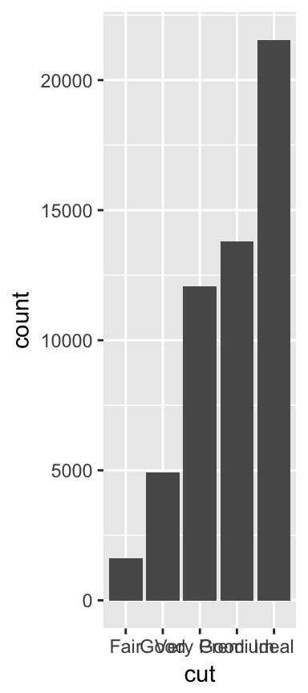

```r
library(ggplot2)
ggplot(diamonds, aes(x = cut)) +
  geom_bar()
```

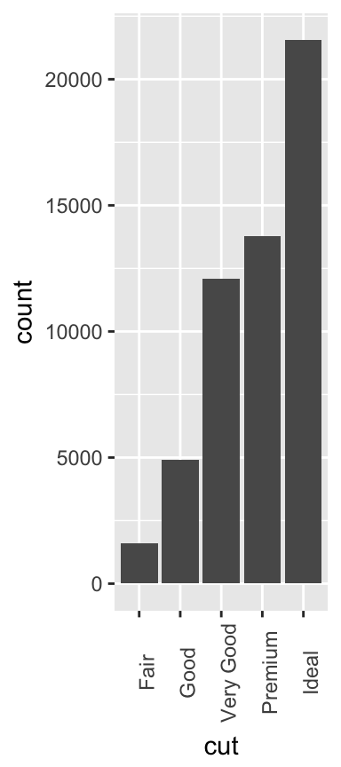

```r
ggplot(diamonds, aes(x = cut)) +
  geom_bar() +
  theme(axis.text.x = element_text(angle = 90))
```

## Tidy Data

## Data Science Cycle

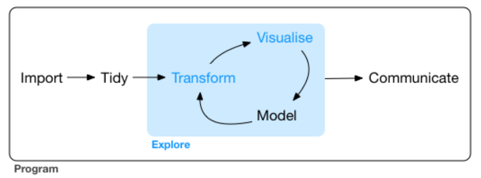

## Tidy Data

Review Handout

## Data set A

```
## # A tibble: 6 x 3
##   country      year rate
## * <chr>       <int> <chr>
## 1 Afghanistan  1999 745/19987071
## 2 Afghanistan  2000 2666/20595360
## 3 Brazil       1999 37737/172006362
## 4 Brazil       2000 80488/174504898
## 5 China        1999 212258/1272915272
## 6 China        2000 213766/1280428583
```

## Data set B

```
## # A tibble: 12 x 4
##    country      year type            count
##    <chr>       <int> <chr>           <int>
##  1 Afghanistan  1999 cases             745
##  2 Afghanistan  1999 population   19987071
##  3 Afghanistan  2000 cases            2666
##  4 Afghanistan  2000 population   20595360
##  5 Brazil       1999 cases           37737
##  6 Brazil       1999 population  172006362
##  7 Brazil       2000 cases           80488
##  8 Brazil       2000 population  174504898
##  9 China        1999 cases          212258
## 10 China        1999 population 1272915272
## 11 China        2000 cases          213766
## 12 China        2000 population 1280428583
```

## Data set C

```
## # A tibble: 6 x 4
##   country      year  cases population
##   <chr>       <int>  <int>      <int>
## 1 Afghanistan  1999    745   19987071
## 2 Afghanistan  2000   2666   20595360
## 3 Brazil       1999  37737  172006362
## 4 Brazil       2000  80488  174504898
## 5 China        1999 212258 1272915272
## 6 China        2000 213766 1280428583
```

## Data set D

```
## # A tibble: 3 x 3
##   country     `1999` `2000`
## * <chr>        <int>  <int>
## 1 Afghanistan    745   2666
## 2 Brazil       37737  80488
## 3 China       212258 213766
```

```
## # A tibble: 3 x 3
##   country         `1999`     `2000`
## * <chr>            <int>      <int>
## 1 Afghanistan   19987071   20595360
## 2 Brazil       172006362  174504898
## 3 China       1272915272 1280428583
```

## Rules of Tidy Data

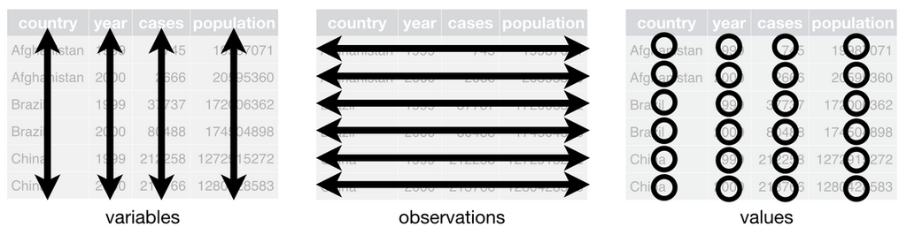

1. Each variable must have its own column
2. Each observation must have its own row
3. Each value must have its own cell

## A tidy data set

```
## # A tibble: 6 x 4
##   country      year  cases population
##   <chr>       <int>  <int>      <int>
## 1 Afghanistan  1999    745   19987071
## 2 Afghanistan  2000   2666   20595360
## 3 Brazil       1999  37737  172006362
## 4 Brazil       2000  80488  174504898
## 5 China        1999 212258 1272915272
## 6 China        2000 213766 1280428583
```

## Untidy data

> Happy families are all alike; every unhappy family is unhappy in its own way.

**Leo Tolstoy**

> Tidy datasets are all alike, but every messy dataset is messy in its own way.

**Hadley Wickham**

## Example D1

What is the problem? How can this be tidied?

```
## # A tibble: 3 x 3
##   country     `1999` `2000`
## * <chr>        <int>  <int>
## 1 Afghanistan    745   2666
## 2 Brazil       37737  80488
## 3 China       212258 213766
```

- Column names are *values* not *variables*.
- We need to *gather* the columns into a new pair of variables.

## Gathering

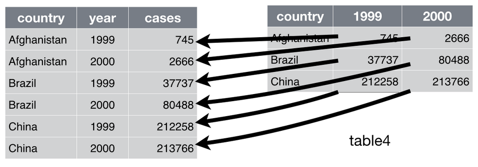

### We need:

1. Set of columns that represent *values* (`1999`, `2000`)
2. **key**: Name of *variable* whose values form the column names (`year`)
3. **value**: Name of *variable* whose values are spread over the cells (`cases`)

```r
tidyD1 <- D1 %>%
  gather(`1999`, `2000`, key = "year", value = "cases")
tidyD1
```

```
## # A tibble: 6 x 3
##   country     year   cases
##   <chr>       <chr>  <int>
## 1 Afghanistan 1999     745
## 2 Brazil      1999   37737
## 3 China       1999  212258
## 4 Afghanistan 2000    2666
## 5 Brazil      2000   80488
## 6 China       2000  213766
```

### Question:

How do we form the full tidy data set C?

```r
tidyD2 <- D2 %>%
  gather(`1999`, `2000`, key = "year", value = "population")
tidyD1 %>%
  left_join(tidyD2, by = c("country", "year"))
```

```
## # A tibble: 6 x 4
##   country     year   cases population
##   <chr>       <chr>  <int>      <int>
## 1 Afghanistan 1999     745   19987071
## 2 Brazil      1999   37737  172006362
## 3 China       1999  212258 1272915272
## 4 Afghanistan 2000    2666   20595360
## 5 Brazil      2000   80488  174504898
## 6 China       2000  213766 1280428583
```

## Example B

What is the problem? How can this be tidied?

```
## # A tibble: 12 x 4
##    country      year type            count
##    <chr>       <int> <chr>           <int>
##  1 Afghanistan  1999 cases             745
##  2 Afghanistan  1999 population   19987071
##  3 Afghanistan  2000 cases            2666
##  4 Afghanistan  2000 population   20595360
##  5 Brazil       1999 cases           37737
##  6 Brazil       1999 population  172006362
##  7 Brazil       2000 cases           80488
##  8 Brazil       2000 population  174504898
##  9 China        1999 cases          212258
## 10 China        1999 population 1272915272
## 11 China        2000 cases          213766
## 12 China        2000 population 1280428583
```

- Each *observation* is spread across multiple rows.
- We need to *spread* the values of a variable across multiple columns.

## Spreading

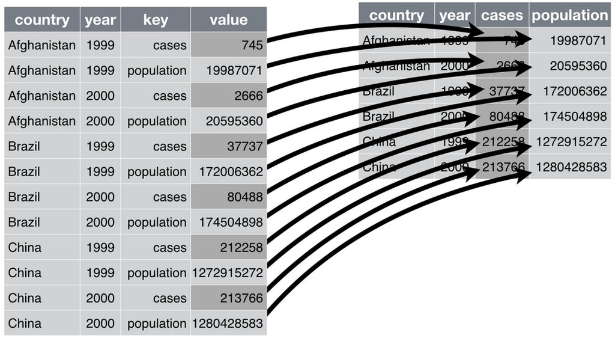

### We need:

1. **key**: Column that contains variable names (`type`)
2. **value**: Column that contains values of multiple variables (`count`)

```r
B %>%
  spread(key = "type", value = "count")
```

```
## # A tibble: 6 x 4
##   country      year  cases population
##   <chr>       <int>  <int>      <int>
## 1 Afghanistan  1999    745   19987071
## 2 Afghanistan  2000   2666   20595360
## 3 Brazil       1999  37737  172006362
## 4 Brazil       2000  80488  174504898
## 5 China        1999 212258 1272915272
## 6 China        2000 213766 1280428583
```

## Big Picture

- Are you representing your data set for **display** or **analysis**?
- If analysis, is your data tidy?
  - Each row a case
  - Each column a variable
  - Each cell a value
- If not, does it need to be reshaped to be "taller" (gathered) or "wider" (spread)

## Practice

Return to the question from Activity 3:

- **3.8**: Which names have been given to M and F most equally?

Solve by untidying `babynames`